# training and testing model

```python
# importing libraries
import numpy as np
import pickle
```

```python
# Shape of Tic Tac Toe Board
BOARD_ROWS = 3
BOARD_COLS = 3
```

```python
# Vectorized function to convert to integer
def f(x):
    return int(x)
f2 = np.vectorize(f)
```

### Tic Tac Toe Game State

```python
# class State => with state and play management for training
class State:
    def __init__(self, p1, p2):
        # initial board state
        self.board = np.zeros((BOARD_ROWS, BOARD_COLS))
        self.p1 = p1
        self.p2 = p2
        self.isEnd = False
        # String Board standings of players
        self.boardHash = None
        # starting with player p1
        self.playerSymbol = 1

    # get unique hash of current board state
    def getHash(self):
        # converting board standing to array
        self.board = np.array([f2(i) for i in list(self.board)])
        # converting array board standings to string as boardHash
        self.boardHash = str(self.board.reshape(BOARD_COLS*BOARD_ROWS))
        return self.boardHash

    # check for the winner
    def winner(self):
        # checking winner for row
        for i in range(BOARD_ROWS):
            # checking winner for p1 for row
            if sum(self.board[i, :]) == 3:
                self.isEnd = True
                return 1
            # checking winner for p2 for row
            if sum(self.board[i, :]) == -3:
                self.isEnd = True
                return -1
        # checking winner for col
        for i in range(BOARD_COLS):
            # checking winner for p1 for row
            if sum(self.board[:, i]) == 3:
                self.isEnd = True
                return 1
            # checking winner for p2 for row
            if sum(self.board[:, i]) == -3:
                self.isEnd = True
                return -1

        # checking winner for diagonals
        diag_sum1 = sum([self.board[i, i] for i in range(BOARD_COLS)])
        diag_sum2 = sum([self.board[i, BOARD_COLS-i-1] for i in range(BOARD_COLS)])
        # checking winner for p1 for diagonals
        if diag_sum1 == 3 or diag_sum2 == 3:
            self.isEnd = True
            return 1
        # checking winner for p2 for diagonals
        if diag_sum1 == -3 or diag_sum2 == -3:
            self.isEnd = True
            return -1

        # checking for tie
        # no available positions
        if len(self.availablePositions()) == 0:
            self.isEnd = True
            return 0
        # not end
        self.isEnd = False
        return None

    # check for empty positions in the board
    def availablePositions(self):
        positions = []
        for i in range(BOARD_ROWS):
            for j in range(BOARD_COLS):
                if self.board[i, j] == 0:
                    positions.append((i, j))  # need to be tuple
        return positions

    # updating the board state as player makes a move with playerSymbol
    def updateState(self, position):
        self.board[position] = self.playerSymbol
        # switch to another player
        self.playerSymbol = -1 if self.playerSymbol == 1 else 1

    # Giving rewards only when game ends
    # result = 1 => win for p1
    # result = -1 => win for p2
    def giveReward(self):
        # getting the game result
        result = self.winner()
        # giving rewards according to result
        if result == 1:
            # giving rewards when p1 wins
            self.p1.feedReward(1)
            self.p2.feedReward(0)
        elif result == -1:
            # giving rewards when p2 wins
            self.p1.feedReward(0)
            self.p2.feedReward(1)
        else:
            # giving rewards when the game is a tie
            # giving less rewards for tie
            self.p1.feedReward(0.001)
            self.p2.feedReward(0.001)

    # resetting the board for new game
    def reset(self):
        # initializing the board and other flags for new game
        self.board = np.zeros((BOARD_ROWS, BOARD_COLS))
        self.boardHash = None
        self.isEnd = False
        self.playerSymbol = 1

    # playing function for playing against each other
    def play(self, rounds=100):
        # playing for given number of rounds of game
        for i in range(rounds):
            if i%1000 == 0:
                print("Rounds {}".format(i))
            while not self.isEnd:
                # Player p1 -> As first move is always made by player p1

                # getting available positions in the board
                positions = self.availablePositions()
                # getting action for player p1
                p1_action = self.p1.chooseAction(positions, self.board, self.playerSymbol)
                # taking action and upating board state
                self.updateState(p1_action)
                board_hash = self.getHash()
                self.p1.addState(board_hash)

                # check board status if it is tie/win
                win = self.winner()
                if win is not None:
                    # game ended with p1 either win or draw
                    self.giveReward()
                    self.p1.reset()
                    self.p2.reset()
                    self.reset()
                    break

                else:
                    # Player 2

                    # getting available positions in the board
                    positions = self.availablePositions()
                    # getting action for player p1
                    p2_action = self.p2.chooseAction(positions, self.board, self.playerSymbol)
                    # taking action and upating board state
                    self.updateState(p2_action)
                    board_hash = self.getHash()
                    self.p2.addState(board_hash)

                    # check board status if it is tie/win
                    win = self.winner()
                    if win is not None:
                        # game ended with p2 either win or draw
                        self.giveReward()
                        self.p1.reset()
                        self.p2.reset()
                        self.reset()
                        break

    # playing function for player p1 playing with human
    # For testing and main game
    def play2(self):
        while not self.isEnd:
            # Player 1
            # first move is always made by player p1

            # getting available positions in the board
            positions = self.availablePositions()
            # getting action for player p1
            p1_action = self.p1.chooseAction(positions, self.board, self.playerSymbol)
            # taking action and upating board state
            self.updateState(p1_action)
            self.showBoard()

            # check board status if it is tie/win
            win = self.winner()
            if win is not None:
                if win == 1:
                    # p1 wins
                    print(self.p1.name, "wins!")
                else:
                    # game is a tie
                    print("tie!")
                self.reset()
                break

            else:
                # Player 2 => Human

                # getting available positions in the board
                positions = self.availablePositions()
                # getting action for player p1
                p2_action = self.p2.chooseAction(positions)
                # taking action and upating board state
                self.updateState(p2_action)
                self.showBoard()

                # check board status if it is tie/win
                win = self.winner()
                if win is not None:
                    if win == -1:
                        # human player wins
                        print(self.p2.name, "wins!")
                    else:
                        # game is a tie
                        print("tie!")
                    self.reset()
                    break

    # Displaying game board
    def showBoard(self):
        # palyer symbols
        # p1: x  p2/human: o
        for i in range(0, BOARD_ROWS):
            print('-------------')
            out = '| '
            for j in range(0, BOARD_COLS):
                if self.board[i, j] == 1:
                    token = 'x'
                if self.board[i, j] == -1:
                    token = 'o'
                if self.board[i, j] == 0:
                    token = ' '
                out += token + ' | '
            print(out)
        print('-------------')
```

### Training players with Simple Monte Carlo Method with Bellman Equation and exploitation rate of 70% -> 0.3

```python
class Player:
    def __init__(self, name, exp_rate=0.3):
        self.name = name # name of the player
        self.states = []  # record all positions taken
        self.exp_rate = exp_rate # exploitation rate -> default as 0.3 => 70%
        # define the gamma value (discount factor)
        self.decay_gamma = 0.9
        self.states_value = {}  # state -> value


    # get unique hash of current board state
    def getHash(self, board):
        # converting board standing to array
        board = np.array([f2(i) for i in list(board)])
         # converting array board standings to string as boardHash
        boardHash = str(board.reshape(BOARD_COLS*BOARD_ROWS))
        return boardHash

    # Generating next action of the player
    def chooseAction(self, positions, current_board, symbol):
        # getting next action randomly on the basis of exploitation value
        if np.random.uniform(0, 1) <= self.exp_rate:
            # This part is mainly for training purpose only
            # take random action
            idx = np.random.choice(len(positions))
            action = positions[idx]
        else:
            # This part is for game play
            # For gameplay the exploitation value is 0
            # Here next action is selected according to the saved policy
            value_max = -999
            for p in positions:
                next_board = current_board.copy()
                next_board[p] = symbol
                next_boardHash = self.getHash(next_board)
                # getting the next action value from the saved policy of the player during training
                value = 0 if self.states_value.get(next_boardHash) is None else self.states_value.get(next_boardHash)
                # print("value", value)
                if value >= value_max:
                    value_max = value
                    action = p
        return action

    # appending a hash state
    def addState(self, state):
        self.states.append(state)

    # updating state values with calculated rewards
    def feedReward(self, reward):
        for st in reversed(self.states):
            if self.states_value.get(st) is None:
                self.states_value[st] = 0
             # Reward Calculation => Simple Monte Carlo Method with Bellman Equation
            self.states_value[st] = (reward + self.decay_gamma*self.states_value[st])
            reward = self.states_value[st]

    # Resetting the states
    def reset(self):
        self.states = []

    # Saving the players game policies
    def savePolicy(self):
        fw = open('policy_' + str(self.name), 'wb')
        pickle.dump(self.states_value, fw)
        fw.close()

    # loding the saved policy
    def loadPolicy(self, file):
        fr = open(file,'rb')
        self.states_value = pickle.load(fr)
        fr.close()
```

```python
p1 = Player("p1_m1")
p2 = Player("p2_m1")

st = State(p1, p2)
print("training...")
st.play(50000)
```

```
training...
Rounds 0
Rounds 1000
Rounds 2000
Rounds 3000
Rounds 4000
Rounds 5000
Rounds 6000
Rounds 7000
Rounds 8000
Rounds 9000
Rounds 10000
Rounds 11000
Rounds 12000
Rounds 13000
Rounds 14000
Rounds 15000
Rounds 16000
Rounds 17000
Rounds 18000
Rounds 19000
Rounds 20000
Rounds 21000
Rounds 22000
Rounds 23000
Rounds 24000
Rounds 25000
Rounds 26000
Rounds 27000
Rounds 28000
Rounds 29000
Rounds 30000
Rounds 31000
Rounds 32000
Rounds 33000
Rounds 34000
Rounds 35000
Rounds 36000
Rounds 37000
Rounds 38000
Rounds 39000
Rounds 40000
Rounds 41000
Rounds 42000
Rounds 43000
Rounds 44000
Rounds 45000
Rounds 46000
Rounds 47000
Rounds 48000
Rounds 49000
```

```python
# Saving policies
p1.savePolicy()
p2.savePolicy()
```

```python
# checking player 1 -> p1 state values -> policies
list(p1.states_value.items())[:5]
```

```
[('[ 1  1 -1 -1  1 -1  1 -1  1]', 9.999999995371166),
 ('[ 0  1  0 -1  1 -1  1 -1  1]', 99.99976823586913),
 ('[ 0  0  0  0  1 -1  1 -1  1]', 129.46498526985957),
 ('[ 0  0  0  0  0  0  1 -1  1]', 1642.6658966688206),
 ('[0 0 0 0 0 0 0 0 1]', 17221.523831251823)]
```

```python
# checking player 2 -> p2 state values -> policies
list(p2.states_value.items())[:5]
```

```
[('[ 0  1 -1 -1  1 -1  1 -1  1]', 0.0),
 ('[ 0  0  0 -1  1 -1  1 -1  1]', 0.0),
 ('[ 0  0  0  0  0 -1  1 -1  1]', 289.6492019654847),
 ('[ 0  0  0  0  0  0  0 -1  1]', 4197.349537972866),
 ('[ 0  1 -1  0  0 -1  1  1 -1]', 7.175704635190001)]
```

```python
# Function for converting integer board values to string values
def getboardhash(board):
    boardHash = str(board.reshape(BOARD_COLS*BOARD_ROWS))
    return boardHash

# Function to combine two players policies and create a new combined policy
def create_combined_policy(p1, p2, name):
    p2_statesvalue = p2.states_value
    # getting state values from policy of player p2
    p2_values = list(p2_statesvalue.values())
    # initializing p2 states
    p2_states = []
    # cleaning, processing and reversing the p2 state values
    # as p2 symbol is inverse of p1 symbol in its statevalues and policies
    for i in list(p2_statesvalue.keys()):
        temp_values = (i.strip('[').strip(']').strip(' ').split(' '))
        tmp_array = []
        for j in temp_values:
            if (j != ''):
                if int(j) == -1 or int(j) == 1:
                    tmp_array.append(int(j)*-1)
                else:
                    tmp_array.append(0)
        p2_states.append(tmp_array)
    # getting the reversed new p2 statevalues
    p12_statevalues ={}
    for i in range(len(p2_states)):
        board_ = getboardhash(np.array(p2_states[i]))
        value = p2_values[i]
        p12_statevalues[board_] = value

    # combining two policies
    final_policy = {**(p1.states_value), **p12_statevalues}

    # saving the combined policy
    fw = open('policy_' + 'final_'+name, 'wb')
    pickle.dump(final_policy, fw)
    fw.close()
```

```python
# combining the two policies and saving it as final policy
create_combined_policy(p1, p2, 'm1')
```

### Training players with Simple Monte Carlo Method with Bellman Equation and exploitation rate of 80% -> 0.2

```python
class Player:
    def __init__(self, name, exp_rate=0.2):
        self.name = name # name of the player
        self.states = []  # record all positions taken
        self.exp_rate = exp_rate # exploitation rate -> default as 0.2 => 80%
        # define the gamma value (discount factor)
        self.decay_gamma = 0.9
        self.states_value = {}  # state -> value


    # get unique hash of current board state
    def getHash(self, board):
        # converting board standing to array
        board = np.array([f2(i) for i in list(board)])
         # converting array board standings to string as boardHash
        boardHash = str(board.reshape(BOARD_COLS*BOARD_ROWS))
        return boardHash

    # Generating next action of the player
    def chooseAction(self, positions, current_board, symbol):
        # getting next action randomly on the basis of exploitation value
        if np.random.uniform(0, 1) <= self.exp_rate:
            # This part is mainly for training purpose only
            # take random action
            idx = np.random.choice(len(positions))
            action = positions[idx]
        else:
            # This part is for game play
            # For gameplay the exploitation value is 0
            # Here next action is selected according to the saved policy
            value_max = -999
            for p in positions:
                next_board = current_board.copy()
                next_board[p] = symbol
                next_boardHash = self.getHash(next_board)
                # getting the next action value from the saved policy of the player during training
                value = 0 if self.states_value.get(next_boardHash) is None else self.states_value.get(next_boardHash)
                # print("value", value)
                if value >= value_max:
                    value_max = value
                    action = p
        return action

    # appending a hash state
    def addState(self, state):
        self.states.append(state)

    # updating state values with calculated rewards
    def feedReward(self, reward):
        for st in reversed(self.states):
            if self.states_value.get(st) is None:
                self.states_value[st] = 0
             # Reward Calculation => Simple Monte Carlo Method with Bellman Equation
            self.states_value[st] = (reward + self.decay_gamma*self.states_value[st])
            reward = self.states_value[st]

    # Resetting the states
    def reset(self):
        self.states = []

    # Saving the players game policies
    def savePolicy(self):
        fw = open('policy_' + str(self.name), 'wb')
        pickle.dump(self.states_value, fw)
        fw.close()

    # loding the saved policy
    def loadPolicy(self, file):
        fr = open(file,'rb')
        self.states_value = pickle.load(fr)
        fr.close()
```

```python
p1 = Player("p1_m2")
p2 = Player("p2_m2")

st = State(p1, p2)
print("training...")
st.play(50000)
```

```
training...
Rounds 0
Rounds 1000
Rounds 2000
Rounds 3000
Rounds 4000
Rounds 5000
Rounds 6000
Rounds 7000
Rounds 8000
Rounds 9000
Rounds 10000
Rounds 11000
Rounds 12000
Rounds 13000
Rounds 14000
Rounds 15000
Rounds 16000
Rounds 17000
Rounds 18000
Rounds 19000
Rounds 20000
Rounds 21000
Rounds 22000
Rounds 23000
Rounds 24000
Rounds 25000
Rounds 26000
Rounds 27000
Rounds 28000
Rounds 29000
Rounds 30000
Rounds 31000
Rounds 32000
Rounds 33000
Rounds 34000
Rounds 35000
Rounds 36000
Rounds 37000
Rounds 38000
Rounds 39000
Rounds 40000
Rounds 41000
Rounds 42000
Rounds 43000
Rounds 44000
Rounds 45000
Rounds 46000
Rounds 47000
Rounds 48000
Rounds 49000
```

```python
# Saving policies
p1.savePolicy()
p2.savePolicy()
```

```python
# combining the two policies and saving it as final policy
create_combined_policy(p1, p2, 'm2')
```

### Training players with Simple Monte Carlo Method with Bellman Equation and exploitation rate of 90% -> 0.1

```python
class Player:
    def __init__(self, name, exp_rate=0.1):
        self.name = name # name of the player
        self.states = []  # record all positions taken
        self.exp_rate = exp_rate # exploitation rate -> default as 0.1 => 90%
        # define the gamma value (discount factor)
        self.decay_gamma = 0.9
        self.states_value = {}  # state -> value


    # get unique hash of current board state
    def getHash(self, board):
        # converting board standing to array
        board = np.array([f2(i) for i in list(board)])
         # converting array board standings to string as boardHash
        boardHash = str(board.reshape(BOARD_COLS*BOARD_ROWS))
        return boardHash

    # Generating next action of the player
    def chooseAction(self, positions, current_board, symbol):
        # getting next action randomly on the basis of exploitation value
        if np.random.uniform(0, 1) <= self.exp_rate:
            # This part is mainly for training purpose only
            # take random action
            idx = np.random.choice(len(positions))
            action = positions[idx]
        else:
            # This part is for game play
            # For gameplay the exploitation value is 0
            # Here next action is selected according to the saved policy
            value_max = -999
            for p in positions:
                next_board = current_board.copy()
                next_board[p] = symbol
                next_boardHash = self.getHash(next_board)
                # getting the next action value from the saved policy of the player during training
                value = 0 if self.states_value.get(next_boardHash) is None else self.states_value.get(next_boardHash)
                # print("value", value)
                if value >= value_max:
                    value_max = value
                    action = p
        return action

    # appending a hash state
    def addState(self, state):
        self.states.append(state)

    # updating state values with calculated rewards
    def feedReward(self, reward):
        for st in reversed(self.states):
            if self.states_value.get(st) is None:
                self.states_value[st] = 0
             # Reward Calculation => Simple Monte Carlo Method with Bellman Equation
            self.states_value[st] = (reward + self.decay_gamma*self.states_value[st])
            reward = self.states_value[st]

    # Resetting the states
    def reset(self):
        self.states = []

    # Saving the players game policies
    def savePolicy(self):
        fw = open('policy_' + str(self.name), 'wb')
        pickle.dump(self.states_value, fw)
        fw.close()

    # loding the saved policy
    def loadPolicy(self, file):
        fr = open(file,'rb')
        self.states_value = pickle.load(fr)
        fr.close()
```

```python
p1 = Player("p1_m3")
p2 = Player("p2_m3")

st = State(p1, p2)
print("training...")
st.play(50000)
```

```
training...
Rounds 0
Rounds 1000
Rounds 2000
Rounds 3000
Rounds 4000
Rounds 5000
Rounds 6000
Rounds 7000
Rounds 8000
Rounds 9000
Rounds 10000
Rounds 11000
Rounds 12000
Rounds 13000
Rounds 14000
Rounds 15000
Rounds 16000
Rounds 17000
Rounds 18000
Rounds 19000
Rounds 20000
Rounds 21000
Rounds 22000
Rounds 23000
Rounds 24000
Rounds 25000
Rounds 26000
Rounds 27000
Rounds 28000
Rounds 29000
Rounds 30000
Rounds 31000
Rounds 32000
Rounds 33000
Rounds 34000
Rounds 35000
Rounds 36000
Rounds 37000
Rounds 38000
Rounds 39000
Rounds 40000
Rounds 41000
Rounds 42000
Rounds 43000
Rounds 44000
Rounds 45000
Rounds 46000
Rounds 47000
Rounds 48000
Rounds 49000
```

```python
# Saving policies
p1.savePolicy()
p2.savePolicy()
```

```python
# combining the two policies and saving it as final policy
create_combined_policy(p1, p2, 'm3')
```

### Visualization of different saved policies with Simple Monte Carlo Method with Bellman Equation and variable exploitation values

```python
import matplotlib.pyplot as plt
plt.rcParams['figure.figsize'] = (10, 6)
```

```python
# getting the x and y coordinated values of policies for plotting
def get_x_y(p):
    state_values = p.states_value
    x_values = range(len(state_values))
    print("total steps:", len(state_values))
    y_values = [i for j, i in list(state_values.items())]
    return x_values, y_values
```

```python
# Function for generating plots for policies
def generate_plots(methods):
    base_policies = ['policy_p1_','policy_p2_','policy_final_']
    list_of_policies = []
    for each_p in methods:
        for each_bp in base_policies:
            list_of_policies.append(each_bp+each_p)

    for each_policy in list_of_policies:
        p = Player("computer", exp_rate=0)
        p.loadPolicy(each_policy)

        x, y = get_x_y(p)

        plt.scatter(x, y)
        plt.title(each_policy)
        plt.xlabel('Number of Games')
        plt.ylabel('Total Rewards')
        plt.show()
```

```
total steps: 2471
```

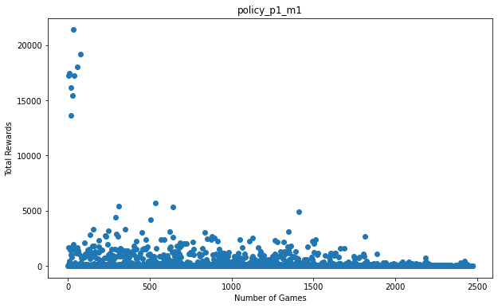

```
total steps: 2480
```

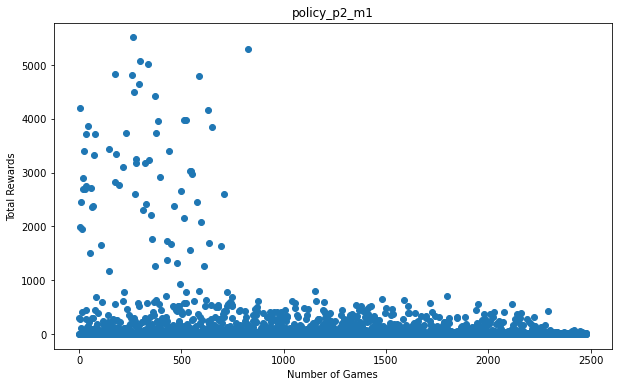

```
total steps: 4951
```

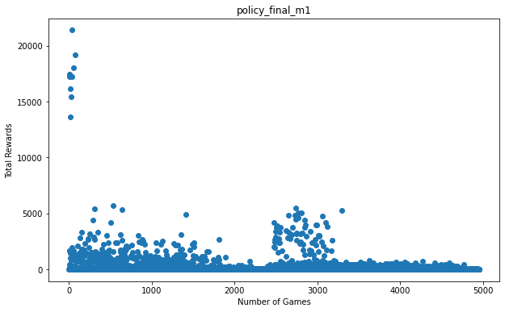

```
total steps: 1875
```

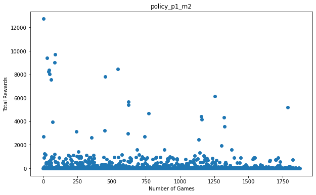

```
total steps: 1844
```

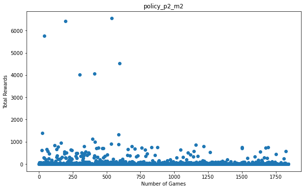

```
total steps: 4560
```

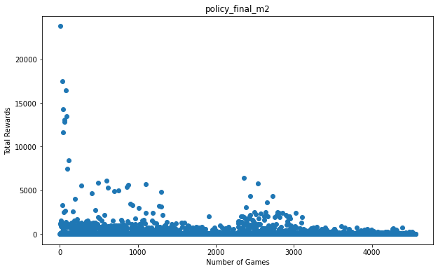

```
total steps: 2010
```

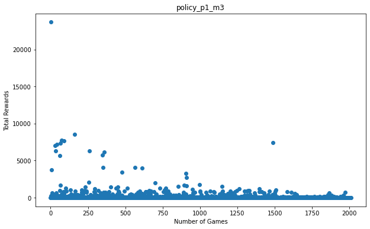

```
total steps: 2024
```

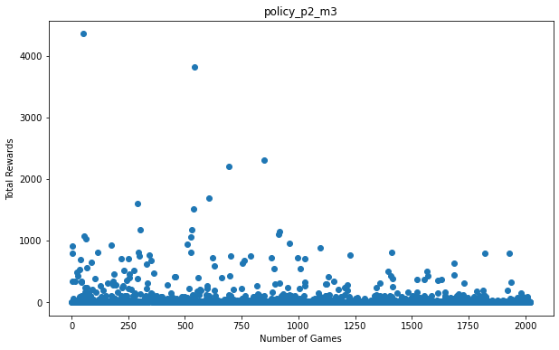

```
total steps: 4034
```

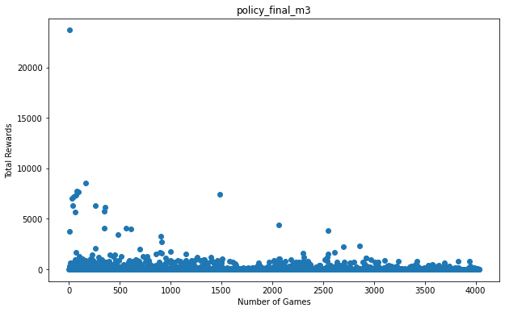

```python
# methods for Simple Monte Carlo Method with Bellman Equation
methods = ['m1', 'm2', 'm3']

# Generating plots for various saved policies
generate_plots(methods)
```

### Training players with SARSA with Monte Carlo Method, exploitation rate of 70% -> 0.3, and fixed learning rate of 0.2

```python
class Player:
    def __init__(self, name, exp_rate=0.3):
        self.name = name # name of the player
        self.states = []  # record all positions taken
        self.lr = 0.2 # learning rate
        self.exp_rate = exp_rate # exploitation rate -> default as 0.3 => 70%
        # define the gamma value (discount factor)
        self.decay_gamma = 0.9
        self.states_value = {}  # state -> value


    # get unique hash of current board state
    def getHash(self, board):
        # converting board standing to array
        board = np.array([f2(i) for i in list(board)])
         # converting array board standings to string as boardHash
        boardHash = str(board.reshape(BOARD_COLS*BOARD_ROWS))
        return boardHash

    # Generating next action of the player
    def chooseAction(self, positions, current_board, symbol):
        # getting next action randomly on the basis of exploitation value
        if np.random.uniform(0, 1) <= self.exp_rate:
            # This part is mainly for training purpose only
            # take random action
            idx = np.random.choice(len(positions))
            action = positions[idx]
        else:
            # This part is for game play
            # For gameplay the exploitation value is 0
            # Here next action is selected according to the saved policy
            value_max = -999
            for p in positions:
                next_board = current_board.copy()
                next_board[p] = symbol
                next_boardHash = self.getHash(next_board)
                # getting the next action value from the saved policy of the player during training
                value = 0 if self.states_value.get(next_boardHash) is None else self.states_value.get(next_boardHash)
                # print("value", value)
                if value >= value_max:
                    value_max = value
                    action = p
        return action

    # appending a hash state
    def addState(self, state):
        self.states.append(state)

    # updating state values with calculated rewards
    def feedReward(self, reward):
        for st in reversed(self.states):
            if self.states_value.get(st) is None:
                self.states_value[st] = 0
            # Reward Calculation => SARSA with Monte Carlo Method
            self.states_value[st] += self.lr*(reward + self.decay_gamma*reward - self.states_value[st])
            reward = self.states_value[st]

    # Resetting the states
    def reset(self):
        self.states = []

    # Saving the players game policies
    def savePolicy(self):
        fw = open('policy_' + str(self.name), 'wb')
        pickle.dump(self.states_value, fw)
        fw.close()

    # loding the saved policy
    def loadPolicy(self, file):
        fr = open(file,'rb')
        self.states_value = pickle.load(fr)
        fr.close()
```

```python
p1 = Player("p1_s1")
p2 = Player("p2_s1")

st = State(p1, p2)
print("training...")
st.play(50000)
```

```
training...
Rounds 0
Rounds 1000
Rounds 2000
Rounds 3000
Rounds 4000
Rounds 5000
Rounds 6000
Rounds 7000
Rounds 8000
Rounds 9000
Rounds 10000
Rounds 11000
Rounds 12000
Rounds 13000
Rounds 14000
Rounds 15000
Rounds 16000
Rounds 17000
Rounds 18000
Rounds 19000
Rounds 20000
Rounds 21000
Rounds 22000
Rounds 23000
Rounds 24000
Rounds 25000
Rounds 26000
Rounds 27000
Rounds 28000
Rounds 29000
Rounds 30000
Rounds 31000
Rounds 32000
Rounds 33000
Rounds 34000
Rounds 35000
Rounds 36000
Rounds 37000
Rounds 38000
Rounds 39000
Rounds 40000
Rounds 41000
Rounds 42000
Rounds 43000
Rounds 44000
Rounds 45000
Rounds 46000
Rounds 47000
Rounds 48000
Rounds 49000
```

```python
# Saving policies
p1.savePolicy()
p2.savePolicy()
```

```python
# combining the two policies and saving it as final policy
create_combined_policy(p1, p2, 's1')
```

### Training players with SARSA with Monte Carlo Method, exploitation rate of 80% -> 0.2, and fixed learning rate of 0.2

```python
class Player:
    def __init__(self, name, exp_rate=0.2):
        self.name = name # name of the player
        self.states = []  # record all positions taken
        self.lr = 0.2 # learning rate
        self.exp_rate = exp_rate # exploitation rate -> default as 0.2 => 80%
        # define the gamma value (discount factor)
        self.decay_gamma = 0.9
        self.states_value = {}  # state -> value


    # get unique hash of current board state
    def getHash(self, board):
        # converting board standing to array
        board = np.array([f2(i) for i in list(board)])
         # converting array board standings to string as boardHash
        boardHash = str(board.reshape(BOARD_COLS*BOARD_ROWS))
        return boardHash

    # Generating next action of the player
    def chooseAction(self, positions, current_board, symbol):
        # getting next action randomly on the basis of exploitation value
        if np.random.uniform(0, 1) <= self.exp_rate:
            # This part is mainly for training purpose only
            # take random action
            idx = np.random.choice(len(positions))
            action = positions[idx]
        else:
            # This part is for game play
            # For gameplay the exploitation value is 0
            # Here next action is selected according to the saved policy
            value_max = -999
            for p in positions:
                next_board = current_board.copy()
                next_board[p] = symbol
                next_boardHash = self.getHash(next_board)
                # getting the next action value from the saved policy of the player during training
                value = 0 if self.states_value.get(next_boardHash) is None else self.states_value.get(next_boardHash)
                # print("value", value)
                if value >= value_max:
                    value_max = value
                    action = p
        return action

    # appending a hash state
    def addState(self, state):
        self.states.append(state)

    # updating state values with calculated rewards
    def feedReward(self, reward):
        for st in reversed(self.states):
            if self.states_value.get(st) is None:
                self.states_value[st] = 0
            # Reward Calculation => SARSA with Monte Carlo Method
            self.states_value[st] += self.lr*(reward + self.decay_gamma*reward - self.states_value[st])
            reward = self.states_value[st]

    # Resetting the states
    def reset(self):
        self.states = []

    # Saving the players game policies
    def savePolicy(self):
        fw = open('policy_' + str(self.name), 'wb')
        pickle.dump(self.states_value, fw)
        fw.close()

    # loding the saved policy
    def loadPolicy(self, file):
        fr = open(file,'rb')
        self.states_value = pickle.load(fr)
        fr.close()
```

```python
p1 = Player("p1_s2")
p2 = Player("p2_s2")

st = State(p1, p2)
print("training...")
st.play(50000)
```

```
training...
Rounds 0
Rounds 1000
Rounds 2000
Rounds 3000
Rounds 4000
Rounds 5000
Rounds 6000
Rounds 7000
Rounds 8000
Rounds 9000
Rounds 10000
Rounds 11000
Rounds 12000
Rounds 13000
Rounds 14000
Rounds 15000
Rounds 16000
Rounds 17000
Rounds 18000
Rounds 19000
Rounds 20000
Rounds 21000
Rounds 22000
Rounds 23000
Rounds 24000
Rounds 25000
Rounds 26000
Rounds 27000
Rounds 28000
Rounds 29000
Rounds 30000
Rounds 31000
Rounds 32000
Rounds 33000
Rounds 34000
Rounds 35000
Rounds 36000
Rounds 37000
Rounds 38000
Rounds 39000
Rounds 40000
Rounds 41000
Rounds 42000
Rounds 43000
Rounds 44000
Rounds 45000
Rounds 46000
Rounds 47000
Rounds 48000
Rounds 49000
```

```python
# Saving policies
p1.savePolicy()
p2.savePolicy()
```

```python
# combining the two policies and saving it as final policy
create_combined_policy(p1, p2, 's2')
```

### Training players with SARSA with Monte Carlo Method, exploitation rate of 90% -> 0.1, and fixed learning rate of 0.2

```python
class Player:
    def __init__(self, name, exp_rate=0.1):
        self.name = name # name of the player
        self.states = []  # record all positions taken
        self.lr = 0.2 # learning rate
        self.exp_rate = exp_rate # exploitation rate -> default as 0.1 => 90%
        # define the gamma value (discount factor)
        self.decay_gamma = 0.9
        self.states_value = {}  # state -> value


    # get unique hash of current board state
    def getHash(self, board):
        # converting board standing to array
        board = np.array([f2(i) for i in list(board)])
         # converting array board standings to string as boardHash
        boardHash = str(board.reshape(BOARD_COLS*BOARD_ROWS))
        return boardHash

    # Generating next action of the player
    def chooseAction(self, positions, current_board, symbol):
        # getting next action randomly on the basis of exploitation value
        if np.random.uniform(0, 1) <= self.exp_rate:
            # This part is mainly for training purpose only
            # take random action
            idx = np.random.choice(len(positions))
            action = positions[idx]
        else:
            # This part is for game play
            # For gameplay the exploitation value is 0
            # Here next action is selected according to the saved policy
            value_max = -999
            for p in positions:
                next_board = current_board.copy()
                next_board[p] = symbol
                next_boardHash = self.getHash(next_board)
                # getting the next action value from the saved policy of the player during training
                value = 0 if self.states_value.get(next_boardHash) is None else self.states_value.get(next_boardHash)
                # print("value", value)
                if value >= value_max:
                    value_max = value
                    action = p
        return action

    # appending a hash state
    def addState(self, state):
        self.states.append(state)

    # updating state values with calculated rewards
    def feedReward(self, reward):
        for st in reversed(self.states):
            if self.states_value.get(st) is None:
                self.states_value[st] = 0
            # Reward Calculation => SARSA with Monte Carlo Method
            self.states_value[st] += self.lr*(reward + self.decay_gamma*reward - self.states_value[st])
            reward = self.states_value[st]

    # Resetting the states
    def reset(self):
        self.states = []

    # Saving the players game policies
    def savePolicy(self):
        fw = open('policy_' + str(self.name), 'wb')
        pickle.dump(self.states_value, fw)
        fw.close()

    # loding the saved policy
    def loadPolicy(self, file):
        fr = open(file,'rb')
        self.states_value = pickle.load(fr)
        fr.close()
```

```python
p1 = Player("p1_s3")
p2 = Player("p2_s3")

st = State(p1, p2)
print("training...")
st.play(50000)
```

```
training...
Rounds 0
Rounds 1000
Rounds 2000
Rounds 3000
Rounds 4000
Rounds 5000
Rounds 6000
Rounds 7000
Rounds 8000
Rounds 9000
Rounds 10000
Rounds 11000
Rounds 12000
Rounds 13000
Rounds 14000
Rounds 15000
Rounds 16000
Rounds 17000
Rounds 18000
Rounds 19000
Rounds 20000
Rounds 21000
Rounds 22000
Rounds 23000
Rounds 24000
Rounds 25000
Rounds 26000
Rounds 27000
Rounds 28000
Rounds 29000
Rounds 30000
Rounds 31000
Rounds 32000
Rounds 33000
Rounds 34000
Rounds 35000
Rounds 36000
Rounds 37000
Rounds 38000
Rounds 39000
Rounds 40000
Rounds 41000
Rounds 42000
Rounds 43000
Rounds 44000
Rounds 45000
Rounds 46000
Rounds 47000
Rounds 48000
Rounds 49000
```

```python
# Saving policies
p1.savePolicy()
p2.savePolicy()
```

```python
# combining the two policies and saving it as final policy
create_combined_policy(p1, p2, 's3')
```

```
total steps: 2558
```

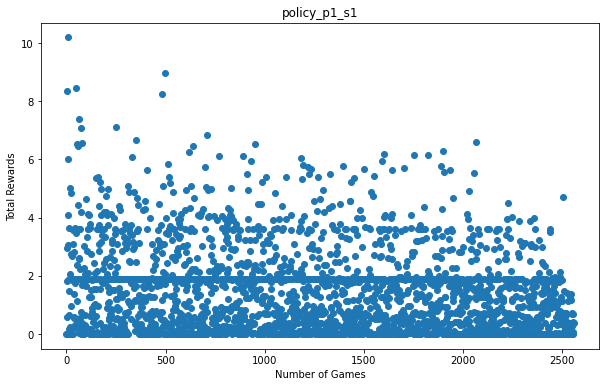

```
total steps: 2542
```

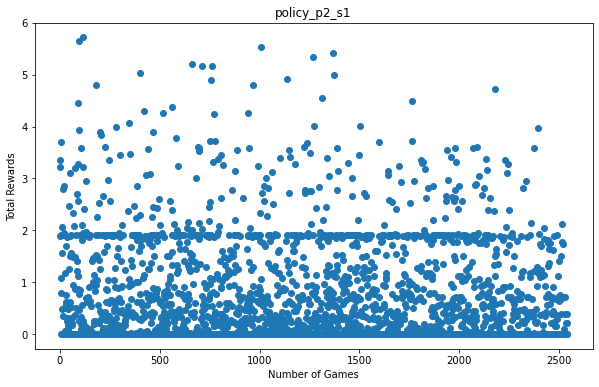

```
total steps: 5100
```

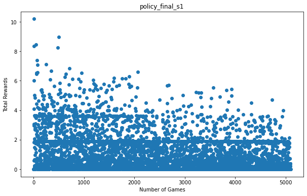

```
total steps: 2377
```

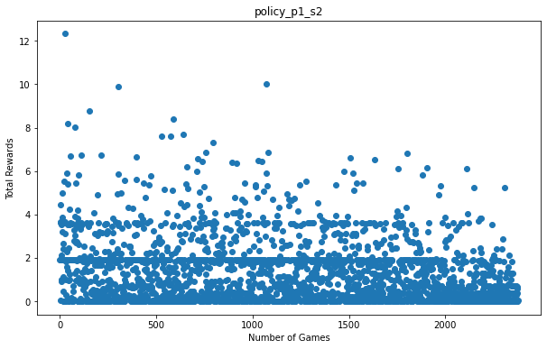

```
total steps: 2347
```

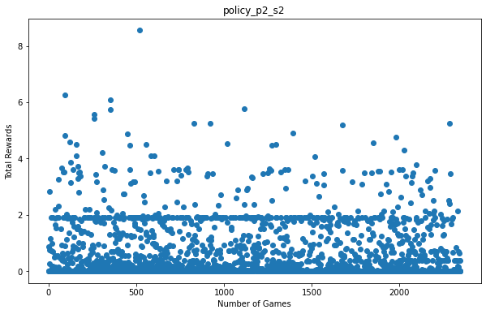

```
total steps: 4724
```

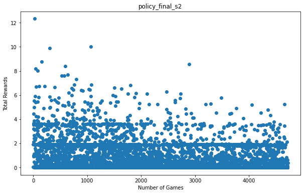

```
total steps: 2220
```

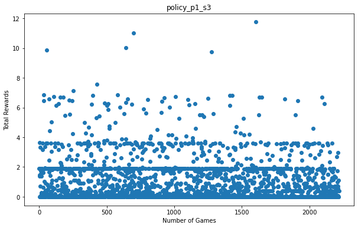

```
total steps: 2240
```

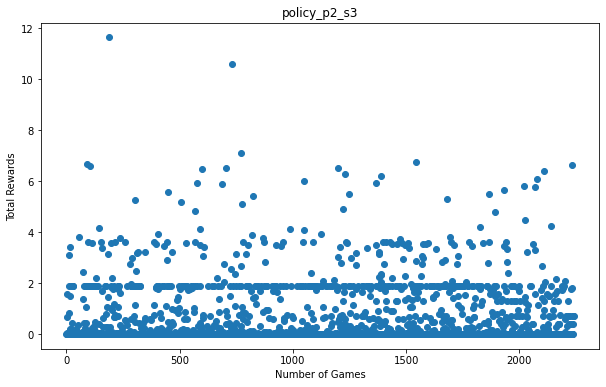

```
total steps: 4460
```

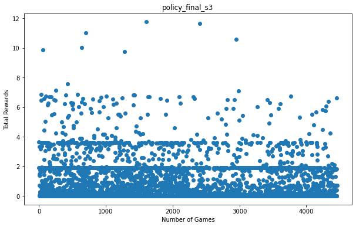

```python
# methods for with SARSA Monte Carlo Method, exploitation rate of 90% -> 0.1,
# and fixed learning rate of 0.2
methods = ['s1', 's2', 's3']

# Generating plots for various saved policies
generate_plots(methods)
```

### Visualization and evaluation of policies

```python
# function for calculating cumulative rewards
def calculate_cumulative_rewards(p):
    state_values = p.states_value
    x_values = range(len(state_values))
    y_values = []
    sum_ = 0
    for j, i in list(state_values.items()):
        sum_ += i
        y_values.append(sum_)
    return x_values, y_values
```

```python
import pandas as pd

# Function for generating plots for policies
def generate_all_plots(methods):
    base_policies = ['policy_p1_','policy_p2_','policy_final_']
    list_of_policies = []
    for each_p in methods:
        for each_bp in base_policies:
            list_of_policies.append(each_bp+each_p)

    # For each policy
    for each_policy in list_of_policies:
        p = Player("computer", exp_rate=0)
        p.loadPolicy(each_policy)

        x, y = calculate_cumulative_rewards(p)

        plt.plot(x, y)
        plt.title(each_policy)
        plt.show()

def generate_combined_plot(methods):
    base_policies = ['policy_p1_','policy_p2_','policy_final_']
    list_of_policies = []
    for each_p in methods:
        for each_bp in base_policies:
            list_of_policies.append(each_bp+each_p)

    # For every policy in a single plot
    cumulative_sum = []
    for each_policy in list_of_policies:
        p = Player("computer", exp_rate=0)
        p.loadPolicy(each_policy)

        x, y = calculate_cumulative_rewards(p)
        cumulative_sum.append([each_policy, y[-1]])
        plt.plot(x, y, label=each_policy)

    plt.xlabel('Number of Games')
    plt.ylabel('Total Rewards')
    plt.legend()
    plt.show()
    return cumulative_sum
```

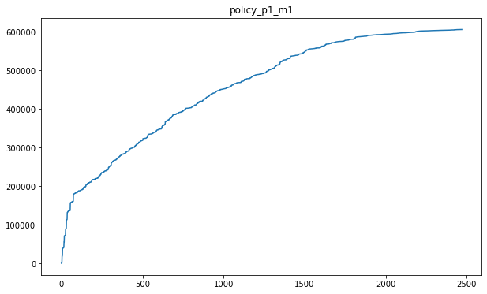

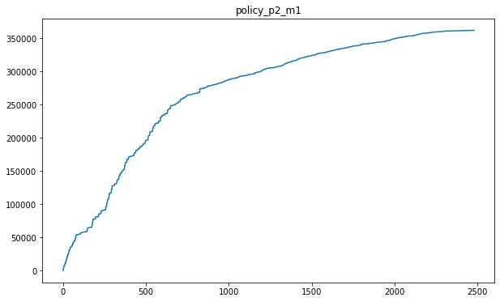

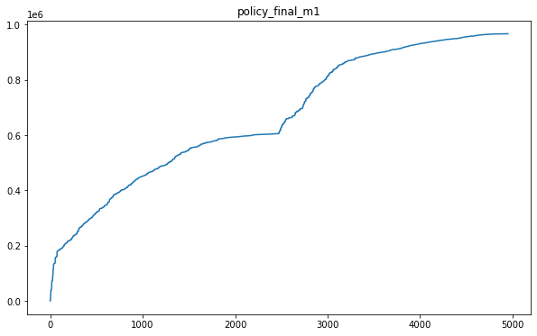

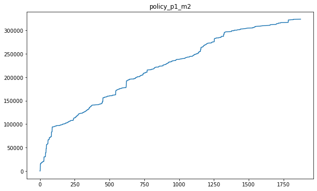

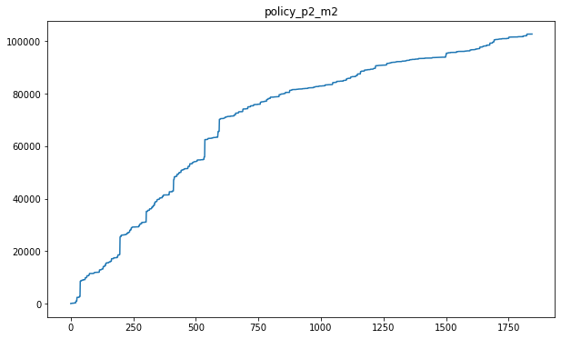

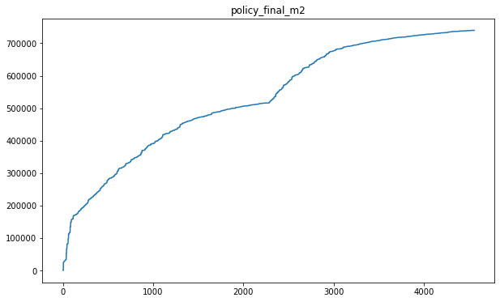

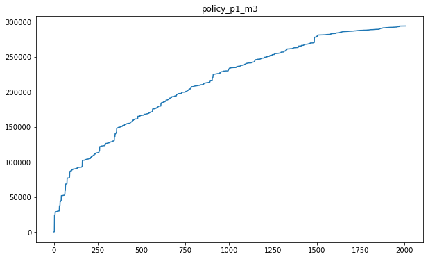

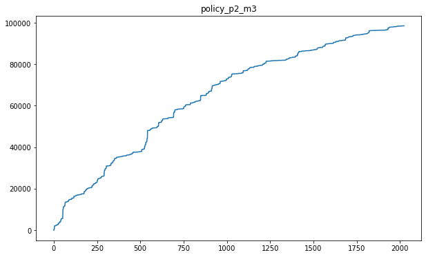

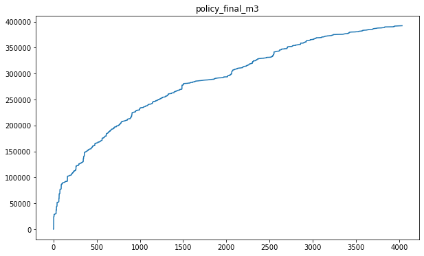

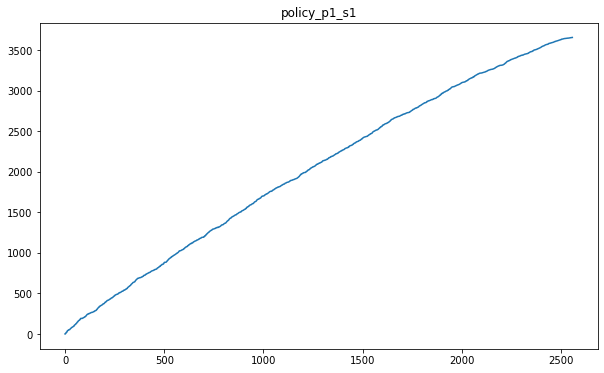

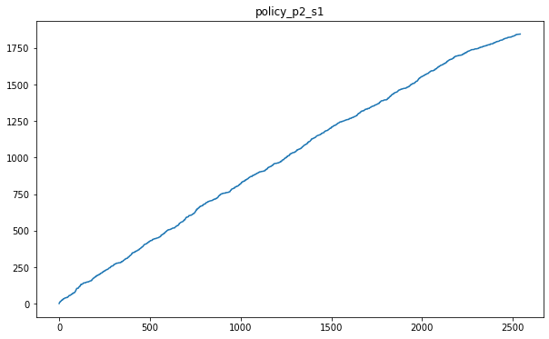

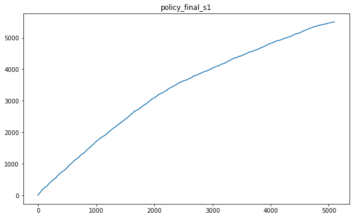

[6 more figures not shown]

```python
# methods for with SARSA Monte Carlo Method, exploitation rate of 90% -> 0.1,
# and fixed learning rate of 0.2
methods = ['m1','m2','m3','s1', 's2', 's3']

# Generating plots for various saved policies
generate_all_plots(methods)
```

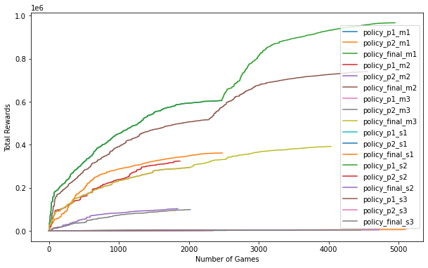

```python
# generating combined plot of all policies with their cumulative sums in every steps
cumulative_sum = generate_combined_plot(methods)
```

From above combined plots of all policies versus their cumulative rewards, we can conclude the ploicy with highest cumulative rewards is 'policy_final_m1'. So, we will be using this policy for the game play.

```python
cumulative_sum
```

```
[['policy_p1_m1', 605475.8361826787],
 ['policy_p2_m1', 361669.2517453013],
 ['policy_final_m1', 967145.0879279781],
 ['policy_p1_m2', 324009.409221854],
 ['policy_p2_m2', 102755.81924495539],
 ['policy_final_m2', 740002.8318180935],
 ['policy_p1_m3', 293787.81637444656],
 ['policy_p2_m3', 98569.8289031059],
 ['policy_final_m3', 392357.6452775534],
 ['policy_p1_s1', 3657.7438354498013],
 ['policy_p2_s1', 1845.8758156422969],
 ['policy_final_s1', 5503.619651092103],
 ['policy_p1_s2', 3128.0512500305204],
 ['policy_p2_s2', 1425.1030815822778],
 ['policy_final_s2', 4553.1543316128045],
 ['policy_p1_s3', 2367.138732093762],
 ['policy_p2_s3', 1306.1948184195319],
 ['policy_final_s3', 3673.3335505133027]]
```

### Playing with the best selected model

```python
class Player:
    def __init__(self, name, exp_rate=0.3):
        self.name = name # name of the player
        self.states = []  # record all positions taken
        self.exp_rate = exp_rate # exploitation rate -> default as 0.3 => 70%
        # define the gamma value (discount factor)
        self.decay_gamma = 0.9
        self.states_value = {}  # state -> value


    # get unique hash of current board state
    def getHash(self, board):
        # converting board standing to array
        board = np.array([f2(i) for i in list(board)])
         # converting array board standings to string as boardHash
        boardHash = str(board.reshape(BOARD_COLS*BOARD_ROWS))
        return boardHash

    # Generating next action of the player
    def chooseAction(self, positions, current_board, symbol):
        # getting next action randomly on the basis of exploitation value
        if np.random.uniform(0, 1) <= self.exp_rate:
            # This part is mainly for training purpose only
            # take random action
            idx = np.random.choice(len(positions))
            action = positions[idx]
        else:
            # This part is for game play
            # For gameplay the exploitation value is 0
            # Here next action is selected according to the saved policy
            value_max = -999
            for p in positions:
                next_board = current_board.copy()
                next_board[p] = symbol
                next_boardHash = self.getHash(next_board)
                # getting the next action value from the saved policy of the player during training
                value = 0 if self.states_value.get(next_boardHash) is None else self.states_value.get(next_boardHash)
                # print("value", value)
                if value >= value_max:
                    value_max = value
                    action = p
        return action

    # appending a hash state
    def addState(self, state):
        self.states.append(state)

    # updating state values with calculated rewards
    def feedReward(self, reward):
        for st in reversed(self.states):
            if self.states_value.get(st) is None:
                self.states_value[st] = 0
             # Reward Calculation => Simple Monte Carlo Method with Bellman Equation
            self.states_value[st] = (reward + self.decay_gamma*self.states_value[st])
            reward = self.states_value[st]

    # Resetting the states
    def reset(self):
        self.states = []

    # Saving the players game policies
    def savePolicy(self):
        fw = open('policy_' + str(self.name), 'wb')
        pickle.dump(self.states_value, fw)
        fw.close()

    # loding the saved policy
    def loadPolicy(self, file):
        fr = open(file,'rb')
        self.states_value = pickle.load(fr)
        fr.close()
```

```python
class HumanPlayer:
    def __init__(self, name):
        self.name = name

    def chooseAction(self, positions):
        while True:
            row = int(input("Input your action row:"))
            col = int(input("Input your action col:"))
            action = (row, col)
            if action in positions:
                return action

    # append a hash state
    def addState(self, state):
        pass

    # at the end of game, backpropagate and update states value
    def feedReward(self, reward):
        pass

    def reset(self):
        pass
```

```python
p1 = Player("computer", exp_rate=0)
p1.loadPolicy("policy_final_m1")

p2 = HumanPlayer("human")

st = State(p1, p2)
st.play2()
```

```
-------------
| x |   |   |
-------------
|   |   |   |
-------------
|   |   |   |
-------------
Input your action row:1
Input your action col:1
-------------
| x |   |   |
-------------
|   | o |   |
-------------
|   |   |   |
-------------
-------------
| x |   |   |
-------------
|   | o | x |
-------------
|   |   |   |
-------------
Input your action row:0
Input your action col:2
-------------
| x |   | o |
-------------
|   | o | x |
-------------
|   |   |   |
-------------
-------------
| x |   | o |
-------------
|   | o | x |
-------------
| x |   |   |
-------------
Input your action row:0
```

[output cut: 17 more lines]

```
-------------
| x | o | o |
-------------
|   | o | x |
-------------
| x | x | o |
-------------
-------------
| x | o | o |
-------------
| x | o | x |
-------------
| x | x | o |
-------------
computer wins!
```